# tidyomics demo

Cameron Williams

2024-07-25

The aim of this analysis session will be to demonstrate how to use a new package, tidyomics, to streamline our Seurat code and make it easier for youse to manipulate single cell datasets.

I’ve set up a new R library with tidyomics installed. Use the following parameters to start up an openondemand session:

Modules: RStudio-Server/2024.04.1+748-Java-11-R-4.4.0 R_LIBS_USER directory: /data/projects/punim1236/R_envs/R-4.4.0_tidyseurat Partition: interactive CPUs: 1 Memory: 40GB

Once the session is ready to go, import tidyomics.

```r
library(Seurat)
library(tidyverse)
library(tidyomics)
library(tidyseurat)
library(purrr)
```

There are two main advantages of the tidyomics package. The most obvious is that it allows us to “pipe” data from one function directly to another using a special operator, `%>%`. Instead of writing functions on consecutive lines and assigning separate outputs, we can simply chain them together.

Here’s how you would create a fresh Seurat object of human splenic stromal cells without piping data:

```r
spleen <- Read10X('/data/scratch/projects/punim1236/human_spleen_3/spleen_3/outs/filtered_feature_bc_matrix')
spleen <- CreateSeuratObject(spleen)
```

Using the pipe operator you can streamline those commands:

```r
Read10X('/data/scratch/projects/punim1236/human_spleen_3/spleen_3/outs/filtered_feature_bc_matrix') %>%
  CreateSeuratObject() ->
  spleen
```

This is also useful when performing QC because it typically requires several functions to perform it completely.

```r
spleen %>%
  mutate(percent.mt = PercentageFeatureSet(spleen, pattern = '^MT-')) %>% ## adds percent.mt column
  subset(subset = nFeature_RNA > 200 & nFeature_RNA < 6000 & percent.mt < 5) ->
  spleen
```

Say we want to visualise only a subset of the data without creating a copy of it or altering the original. The pipe operator helps here as well because we can pipe the output from the `subset()` function into any Seurat plot function, e.g. `VlnPlot()`.

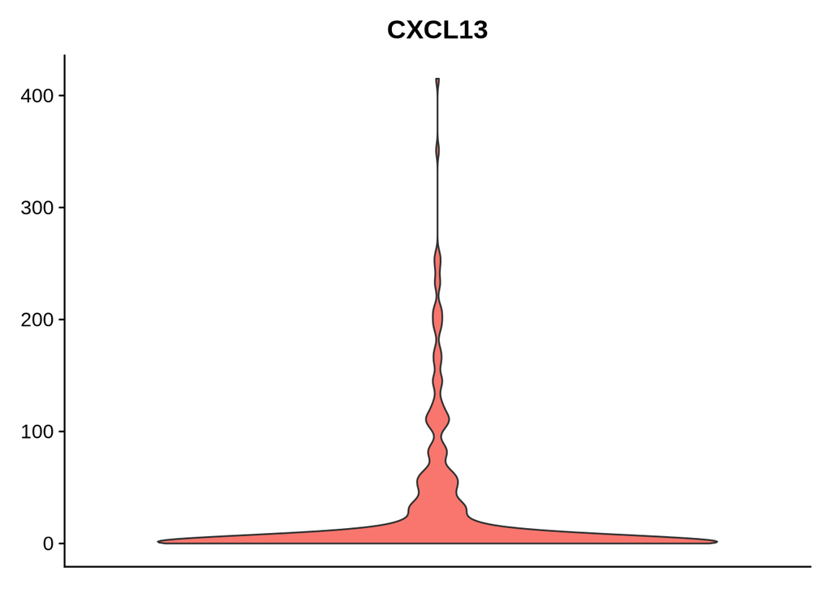

```r
vlntheme <- list(
  theme(axis.text.x = element_blank(),
        axis.title = element_blank(),
        axis.ticks.x = element_blank(),
        legend.position = 'none',
        line = element_line(colour = 'grey50'))
)

## original dataset
spleen %>%
  VlnPlot(features = 'CXCL13', pt.size = 0) +
  vlntheme
```

```
## Normalizing layer: counts
```

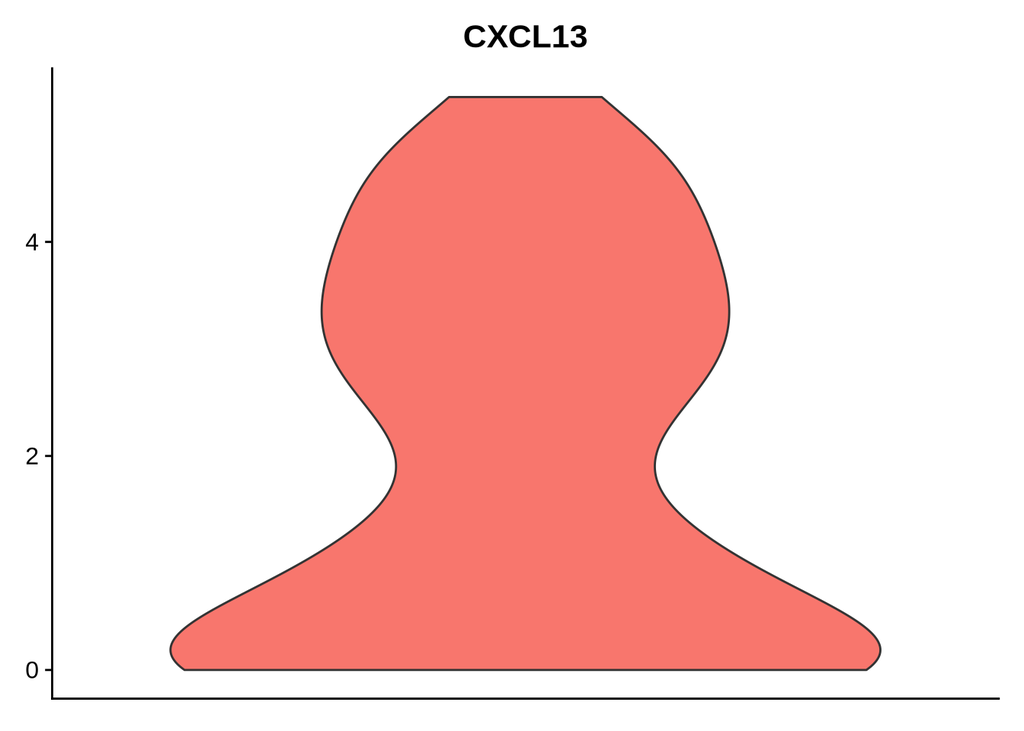

```r
## vs subsetted data, in a single function - we will remove cells expressing CCL21
spleen %>%
  NormalizeData() %>%
  subset(subset = rna_CCL21 == 0) %>%
  VlnPlot(features = 'CXCL13', pt.size = 0) +
  vlntheme
```

Let’s finish preprocessing the data.

```r
spleen %>%
  NormalizeData() %>% FindVariableFeatures() %>% ScaleData() %>% RunPCA() ->
  spleen
```

```
## Normalizing layer: counts
```

```
## Finding variable features for layer counts
```

[output not shown]

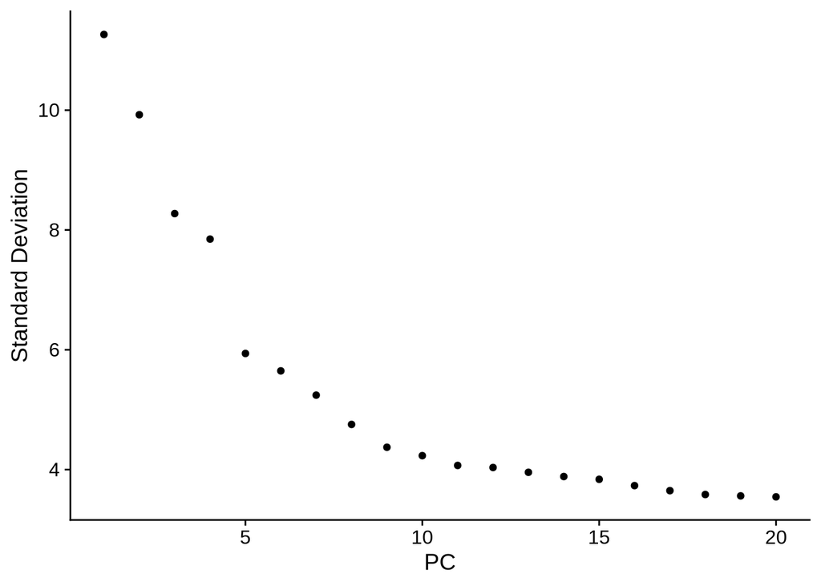

```r
spleen %>% ElbowPlot()
```

Easy as. Let’s run a dimensionality reduction on the first ten PCs vs on the first eight PCs.

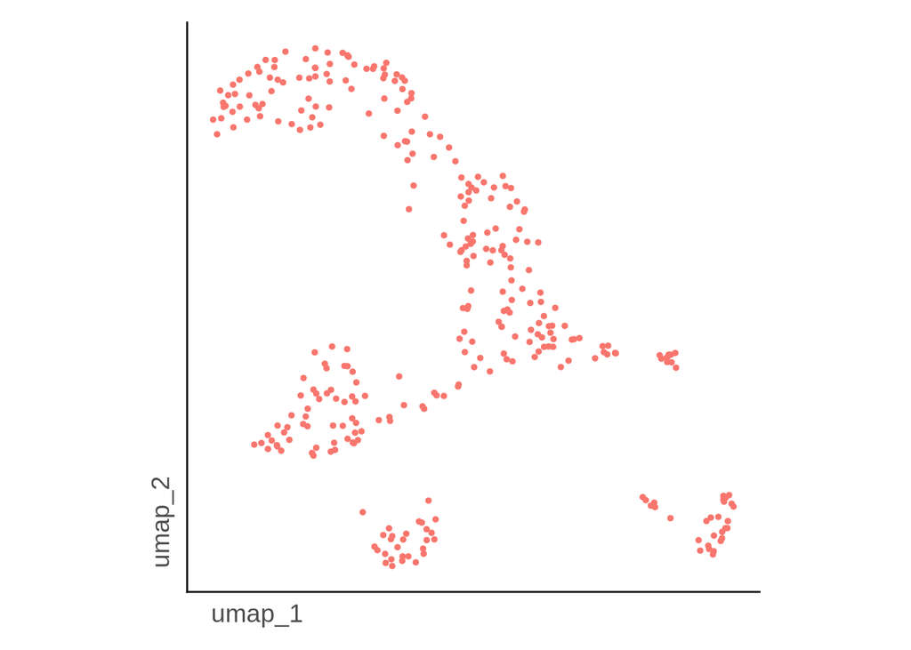

```r
dimtheme <- list(
  coord_fixed(),
  theme(axis.text = element_blank(),
        axis.title = element_text(hjust=0.05, colour='grey30'),
        axis.ticks = element_blank(),
        legend.position = 'none',
        line = element_line(colour = 'grey50'))
)

spleen %>%
  RunUMAP(dims = 1:10) %>%
  DimPlot() + dimtheme
```

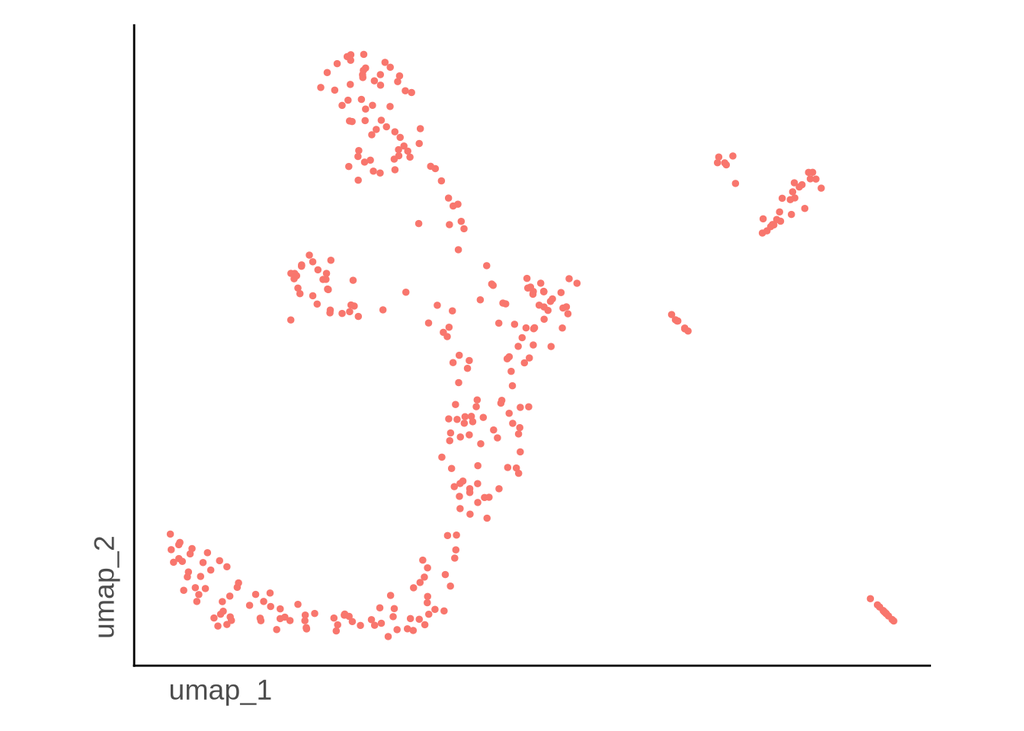

```r
spleen %>%
  RunUMAP(dims = 1:8) %>%
  DimPlot() + dimtheme
```

We can also visualise some metrics in these dimensionality reductions.

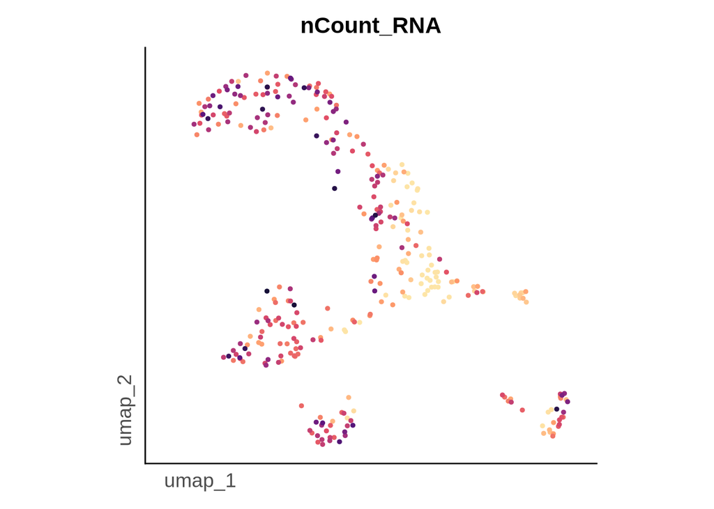

```r
featuretheme <- list(
  coord_fixed(),
  theme(axis.text = element_blank(),
        axis.title = element_text(hjust=0.05, colour='grey30'),
        axis.ticks = element_blank(),
        line = element_line(colour = 'grey50'),
        legend.text = element_blank(),
        legend.title = element_blank())
)

spleen %>%
  RunUMAP(dims = 1:10) %>%
  FeaturePlot(features = 'nCount_RNA', order=T) + dimtheme +
  scale_colour_viridis_c(option = 'magma', direction=-1, begin=0.1, end=0.95)
```

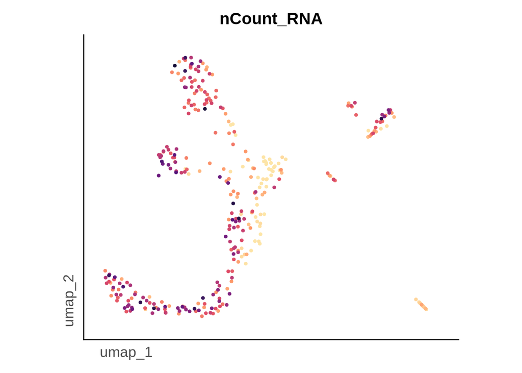

```r
spleen %>%
  RunUMAP(dims = 1:8) %>%
  FeaturePlot(features = 'nCount_RNA', order=T) + dimtheme +
  scale_colour_viridis_c(option = 'magma', direction=-1, begin=0.1, end=0.95)
```

Let’s assign the 10 PC UMAP to the `spleen` object for no particular reason.

```r
RunUMAP(spleen, dims=1:10) -> spleen
```

Finally, we can also easily test different clustering parameters with this method.

```
## Modularity Optimizer version 1.3.0 by Ludo Waltman and Nees Jan van Eck
##
## Number of nodes: 329
## Number of edges: 12782
##
## Running Louvain algorithm...
## Maximum modularity in 10 random starts: 0.6417
## Number of communities: 5
## Elapsed time: 0 seconds
```

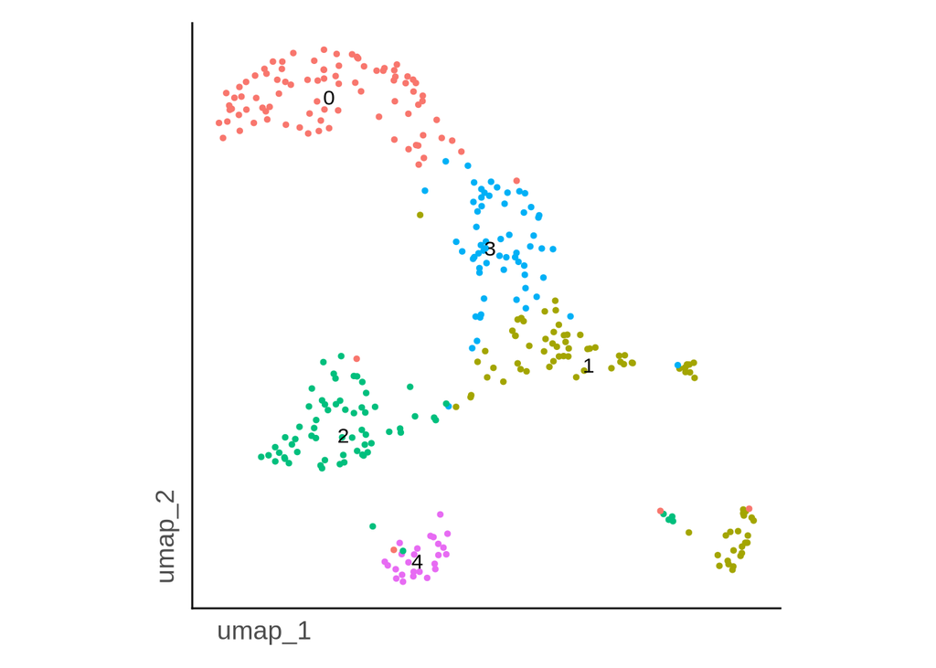

```r
spleen %>%
  FindNeighbors(dims = 1:10, k=30) %>%
  FindClusters(resolution = 1) %>%
  DimPlot(label=T) + dimtheme
```

```
## Modularity Optimizer version 1.3.0 by Ludo Waltman and Nees Jan van Eck
##
## Number of nodes: 329
## Number of edges: 20934
##
## Running Louvain algorithm...
## Maximum modularity in 10 random starts: 0.5348
## Number of communities: 3
## Elapsed time: 0 seconds
```

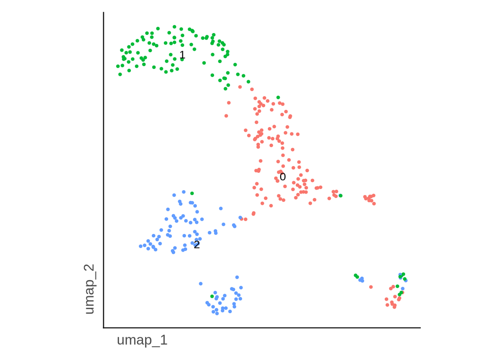

```r
spleen %>%
  FindNeighbors(dims = 1:10, k=50) %>%
  FindClusters(resolution = 1) %>%
  DimPlot(label=T) + dimtheme
```

```
## Modularity Optimizer version 1.3.0 by Ludo Waltman and Nees Jan van Eck
##
## Number of nodes: 329
## Number of edges: 20934
##
## Running Louvain algorithm...
## Maximum modularity in 10 random starts: 0.2114
## Number of communities: 13
## Elapsed time: 0 seconds
```

```
## 2 singletons identified. 11 final clusters.
```

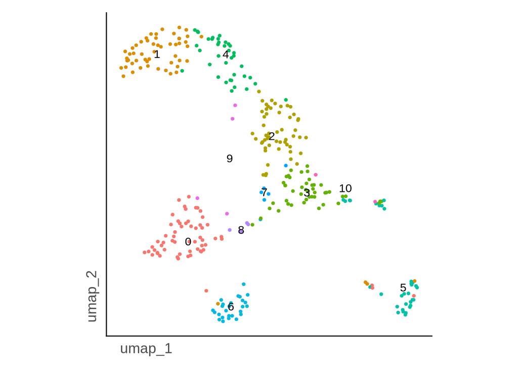

```r
spleen %>%
  FindNeighbors(dims = 1:10, k=50) %>%
  FindClusters(resolution = 2.5) %>%
  DimPlot(label=T) + dimtheme
```

Let’s assign the output of the last one, just because.

```r
spleen %>%
  FindNeighbors(dims = 1:10, k=50) %>%
  FindClusters(resolution = 2.5) ->
  spleen
```

```
## Modularity Optimizer version 1.3.0 by Ludo Waltman and Nees Jan van Eck
##
## Number of nodes: 329
## Number of edges: 20934
##
## Running Louvain algorithm...
## Maximum modularity in 10 random starts: 0.2114
## Number of communities: 13
## Elapsed time: 0 seconds
```

```
## 2 singletons identified. 11 final clusters.
```

Finally, you can also easily create new variables to plot or on which to subset without having to create save that variable to your Seurat object using the `mutate()` function. We can demonstrate this by creating and plotting a variable encoding which cells are positive for CXCL13.

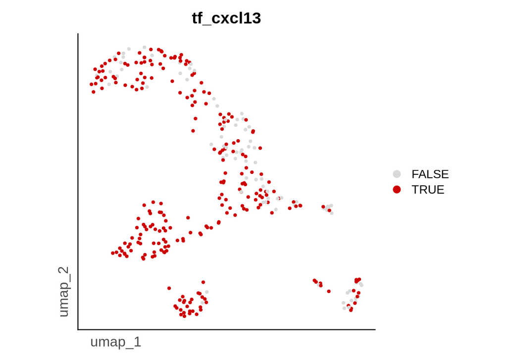

```r
spleen %>%
  mutate(tf_cxcl13 = FetchData(spleen, 'CXCL13') > 0) %>%
  DimPlot(group.by = 'tf_cxcl13', cols = c('grey85','red3')) +
  dimtheme + theme(legend.position = 'right')
```

```r
spleen %>%
  mutate(groups = as.factor(FetchData(spleen, 'CXCL13') > 0)) %>%
  aggregate_cells(groups, assays = "RNA") ->
  spleen_agg
```